# CART_RF

# CART & Random Forest

```r
set.seed(67)
```

According to the documentation, this data set include “[…] radar data was collected by a system in Goose Bay, Labrador. This system consists of a phased array of 16 high-frequency antennas with a total transmitted power on the order of 6.4 kilowatts. […] The targets were free electrons in the ionosphere.”good” radar returns are those showing evidence of some type of structure in the ionosphere. “bad” returns are those that do not; their signals pass through the ionosphere.” [source](https://www.rdocumentation.org/packages/mlbench/versions/2.1-3/topics/Ionosphere).

## EDA

```r
summary(Ionosphere)
```

```
##  V1      V2            V3                V4                 V5
##  0: 38   0:351   Min.   :-1.0000   Min.   :-1.00000   Min.   :-1.0000
##  1:313           1st Qu.: 0.4721   1st Qu.:-0.06474   1st Qu.: 0.4127
##                  Median : 0.8711   Median : 0.01631   Median : 0.8092
##                  Mean   : 0.6413   Mean   : 0.04437   Mean   : 0.6011
##                  3rd Qu.: 1.0000   3rd Qu.: 0.19418   3rd Qu.: 1.0000
##                  Max.   : 1.0000   Max.   : 1.00000   Max.   : 1.0000
##        V6                V7                V8                 V9
##  Min.   :-1.0000   Min.   :-1.0000   Min.   :-1.00000   Min.   :-1.00000
##  1st Qu.:-0.0248   1st Qu.: 0.2113   1st Qu.:-0.05484   1st Qu.: 0.08711
##  Median : 0.0228   Median : 0.7287   Median : 0.01471   Median : 0.68421
##  Mean   : 0.1159   Mean   : 0.5501   Mean   : 0.11936   Mean   : 0.51185
##  3rd Qu.: 0.3347   3rd Qu.: 0.9692   3rd Qu.: 0.44567   3rd Qu.: 0.95324
##  Max.   : 1.0000   Max.   : 1.0000   Max.   : 1.00000   Max.   : 1.00000
##       V10                V11                V12                V13
##  Min.   :-1.00000   Min.   :-1.00000   Min.   :-1.00000   Min.   :-1.0000
##  1st Qu.:-0.04807   1st Qu.: 0.02112   1st Qu.:-0.06527   1st Qu.: 0.0000
##  Median : 0.01829   Median : 0.66798   Median : 0.02825   Median : 0.6441
##  Mean   : 0.18135   Mean   : 0.47618   Mean   : 0.15504   Mean   : 0.4008
##  3rd Qu.: 0.53419   3rd Qu.: 0.95790   3rd Qu.: 0.48237   3rd Qu.: 0.9555
##  Max.   : 1.00000   Max.   : 1.00000   Max.   : 1.00000   Max.   : 1.0000
##       V14                V15               V16                V17
##  Min.   :-1.00000   Min.   :-1.0000   Min.   :-1.00000   Min.   :-1.0000
##  1st Qu.:-0.07372   1st Qu.: 0.0000   1st Qu.:-0.08170   1st Qu.: 0.0000
##  Median : 0.03027   Median : 0.6019   Median : 0.00000   Median : 0.5909
##  Mean   : 0.09341   Mean   : 0.3442   Mean   : 0.07113   Mean   : 0.3819
##  3rd Qu.: 0.37486   3rd Qu.: 0.9193   3rd Qu.: 0.30897   3rd Qu.: 0.9357
##  Max.   : 1.00000   Max.   : 1.0000   Max.   : 1.00000   Max.   : 1.0000
##       V18                 V19               V20                V21
##  Min.   :-1.000000   Min.   :-1.0000   Min.   :-1.00000   Min.   :-1.0000
##  1st Qu.:-0.225690   1st Qu.: 0.0000   1st Qu.:-0.23467   1st Qu.: 0.0000
##  Median : 0.000000   Median : 0.5762   Median : 0.00000   Median : 0.4991
##  Mean   :-0.003617   Mean   : 0.3594   Mean   :-0.02402   Mean   : 0.3367
##  3rd Qu.: 0.195285   3rd Qu.: 0.8993   3rd Qu.: 0.13437   3rd Qu.: 0.8949
##  Max.   : 1.000000   Max.   : 1.0000   Max.   : 1.00000   Max.   : 1.0000
##       V22                 V23               V24                V25
##  Min.   :-1.000000   Min.   :-1.0000   Min.   :-1.00000   Min.   :-1.0000
##  1st Qu.:-0.243870   1st Qu.: 0.0000   1st Qu.:-0.36689   1st Qu.: 0.0000
##  Median : 0.000000   Median : 0.5318   Median : 0.00000   Median : 0.5539
##  Mean   : 0.008296   Mean   : 0.3625   Mean   :-0.05741   Mean   : 0.3961
```

[output cut: 8 more lines]

```
##  Max.   : 1.00000   Max.   : 1.0000   Max.   : 1.00000   Max.   : 1.0000
##       V30                V31               V32                 V33
##  Min.   :-1.00000   Min.   :-1.0000   Min.   :-1.000000   Min.   :-1.0000
##  1st Qu.:-0.23689   1st Qu.: 0.0000   1st Qu.:-0.242595   1st Qu.: 0.0000
##  Median : 0.00000   Median : 0.4428   Median : 0.000000   Median : 0.4096
##  Mean   :-0.02791   Mean   : 0.3525   Mean   :-0.003794   Mean   : 0.3494
##  3rd Qu.: 0.15407   3rd Qu.: 0.8576   3rd Qu.: 0.200120   3rd Qu.: 0.8138
##  Max.   : 1.00000   Max.   : 1.0000   Max.   : 1.000000   Max.   : 1.0000
##       V34            Class
##  Min.   :-1.00000   bad :126
##  1st Qu.:-0.16535   good:225
##  Median : 0.00000
##  Mean   : 0.01448
##  3rd Qu.: 0.17166
##  Max.   : 1.00000
```

Based on the “V” variables predictors representing values of the measured electromagnetic field (with both real and complex components), we’ll build a classification and then a Random Forest model in order to predict the *Class* variable about whether a measure is “good” or “bad” (refer to the above description for an interpretation of those categories).

From the initial exploration, we can see that the dataset contains almost twice observations having “class”=good as observation having “class”=bad. Therefore, we’ll have to be careful of this characteristic When drawing conclusions about our models.

## Dataset preparation

1. To build our model, we’ll do a random 80/20 train/test split on our dataset. Because we want to keep the same “good”/“bad” distribution in test and train datasets as in the initial one, we will use the createDataPartition method from the caret package to do so:

```r
library(caret)
set.seed(67)
train_samples <- Ionosphere$Class %>% # return the indexes of the rows
      createDataPartition(p = 0.8, list = FALSE)

Ionosphere.train <- Ionosphere[train_samples, ]
Ionosphere.test <- Ionosphere[-train_samples, ]

split_stats = rbind(summary(Ionosphere$Class)/nrow(Ionosphere)*100, summary(Ionosphere.train$Class)/nrow(Ionosphere.train)*100, summary(Ionosphere.test$Class)/nrow(Ionosphere.test)*100)

print(split_stats)
```

```
##           bad     good
## [1,] 35.89744 64.10256
## [2,] 35.94306 64.05694
## [3,] 35.71429 64.28571
```

```r
print(xtable(split_stats, type="latex"), file="split_stats.tex")
```

The table of the distribution ensures us that the data is well represented in both sets.

## Classification tree

### First iteration

As our first model, we will apply a simple classification tree on the training data then we’ll see how it performs and the test set.

[output not shown]

```r
#Ionosphere.tree.train = rpart(formula = Class ~ V1 + V2 + V3 + V4 + V5 + V6 + V7 + V8 + V9 + V10 + V11 + V12 + V13 + V14 + V15 + V16 + V17 + V18 + V19 + V20 + V21 + V22 + V23 + V24 + V25 + V26 + V27 + V28 + V29 + V30 + V31 + V32 + V33 + V34, data = Ionosphere.train, method="class")
```

We will use different CP values and plot the classification trees in order to study its influence on the computed tree:

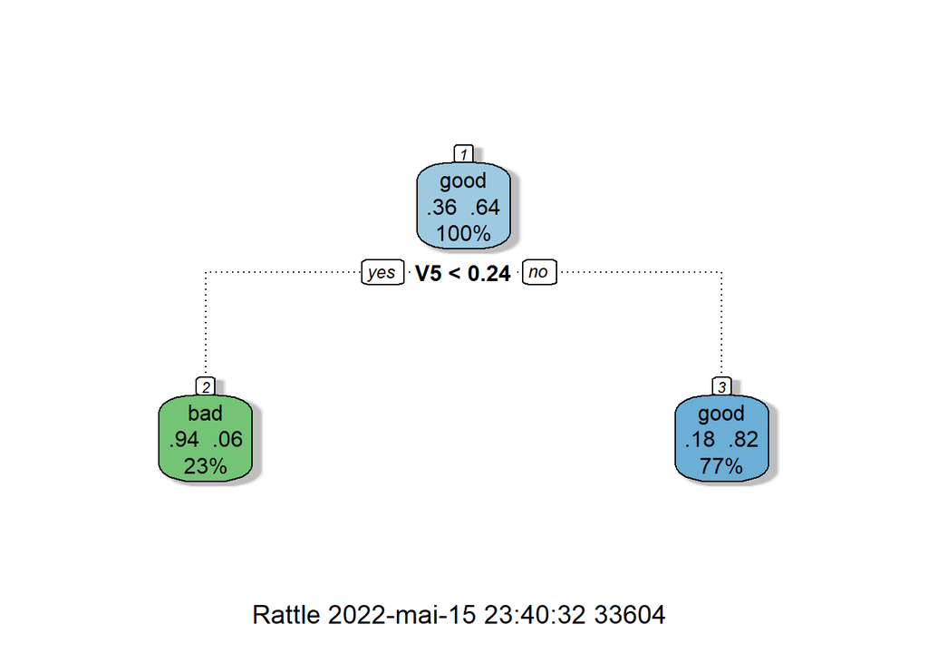

```r
Ionosphere.tree.train = rpart(formula = Class ~ V1 + V2 + V3 + V4 + V5 + V6 + V7 + V8 + V9 + V10 + V11 + V12 + V13 + V14 + V15 + V16 + V17 + V18 + V19 + V20 + V21 + V22 + V23 + V24 + V25 + V26 + V27 + V28 + V29 + V30 + V31 + V32 + V33 + V34, data = Ionosphere.train, method="class", cp=0.3)

fancyRpartPlot(Ionosphere.tree.train)
```

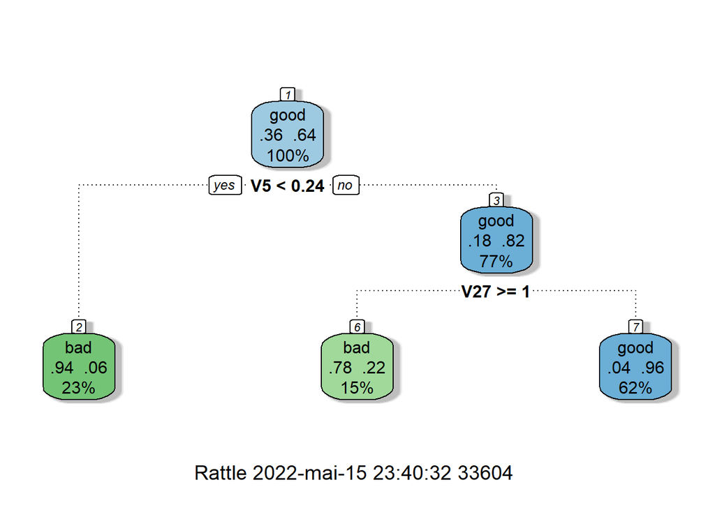

```r
Ionosphere.tree.train = rpart(formula = Class ~ V1 + V2 + V3 + V4 + V5 + V6 + V7 + V8 + V9 + V10 + V11 + V12 + V13 + V14 + V15 + V16 + V17 + V18 + V19 + V20 + V21 + V22 + V23 + V24 + V25 + V26 + V27 + V28 + V29 + V30 + V31 + V32 + V33 + V34, data = Ionosphere.train, method="class", cp=0.2)

fancyRpartPlot(Ionosphere.tree.train)
```

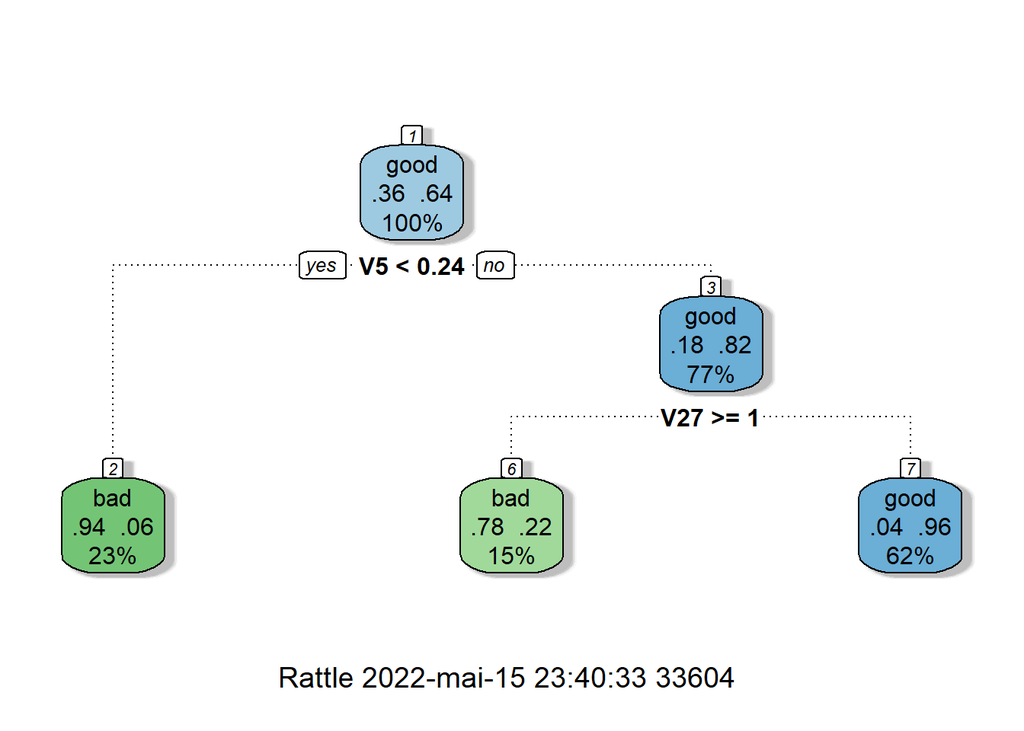

```r
Ionosphere.tree.train = rpart(formula = Class ~ V1 + V2 + V3 + V4 + V5 + V6 + V7 + V8 + V9 + V10 + V11 + V12 + V13 + V14 + V15 + V16 + V17 + V18 + V19 + V20 + V21 + V22 + V23 + V24 + V25 + V26 + V27 + V28 + V29 + V30 + V31 + V32 + V33 + V34, data = Ionosphere.train, method="class", cp=0.1)

fancyRpartPlot(Ionosphere.tree.train)
```

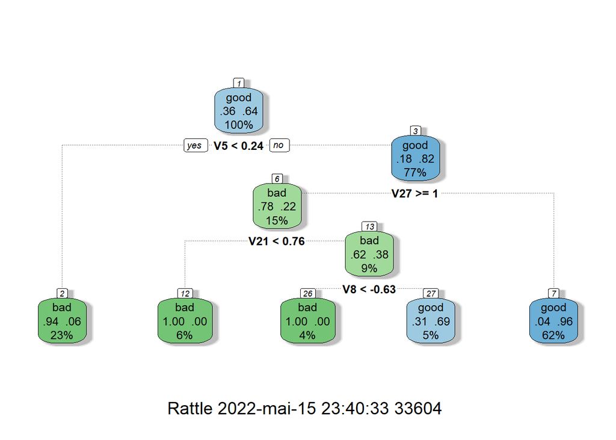

```r
Ionosphere.tree.train = rpart(formula = Class ~ V1 + V2 + V3 + V4 + V5 + V6 + V7 + V8 + V9 + V10 + V11 + V12 + V13 + V14 + V15 + V16 + V17 + V18 + V19 + V20 + V21 + V22 + V23 + V24 + V25 + V26 + V27 + V28 + V29 + V30 + V31 + V32 + V33 + V34, data = Ionosphere.train, method="class", cp=0.005)

fancyRpartPlot(Ionosphere.tree.train)
```

**Answer b)** Here is the classification tree for a default run:

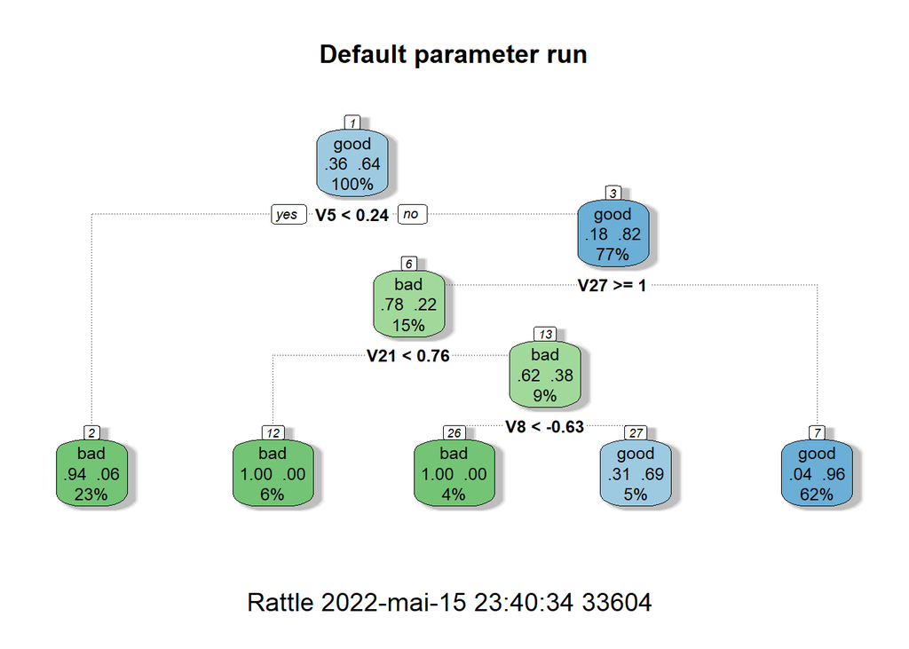

```r
Ionosphere.tree.train = rpart(formula = Class ~ V1 + V2 + V3 + V4 + V5 + V6 + V7 + V8 + V9 + V10 + V11 + V12 + V13 + V14 + V15 + V16 + V17 + V18 + V19 + V20 + V21 + V22 + V23 + V24 + V25 + V26 + V27 + V28 + V29 + V30 + V31 + V32 + V33 + V34, data = Ionosphere.train, method="class")

fancyRpartPlot(Ionosphere.tree.train, main="Default parameter run")
```

```r
Ionosphere.tree.train
```

```
## n= 281
##
## node), split, n, loss, yval, (yprob)
##       * denotes terminal node
##
##  1) root 281 101 good (0.35943060 0.64056940)
##    2) V5< 0.23569 66   4 bad (0.93939394 0.06060606) *
##    3) V5>=0.23569 215  39 good (0.18139535 0.81860465)
##      6) V27>=0.999945 41   9 bad (0.78048780 0.21951220)
##       12) V21< 0.7637 17   0 bad (1.00000000 0.00000000) *
##       13) V21>=0.7637 24   9 bad (0.62500000 0.37500000)
##         26) V8< -0.628545 11   0 bad (1.00000000 0.00000000) *
##         27) V8>=-0.628545 13   4 good (0.30769231 0.69230769) *
##      7) V27< 0.999945 174   7 good (0.04022989 0.95977011) *
```

### Performance test

Now, we can apply this classification tree to the test dataset and conclude about its performances.

```r
pred = predict(Ionosphere.tree.train, Ionosphere.test, type="class")
before_cp_a <- mean(pred==Ionosphere.test$Class)
before_cp_a
```

```
## [1] 0.7857143
```

**Answer d)** Therefore, we have misclassified observations which can also be seen under a confusion matrix:

```r
table(pred=pred, true=Ionosphere.test$Class)
```

```
##       true
## pred   bad good
##   bad   13    3
##   good  12   42
```

But as we said before, there is a consequent disparity in the repartition of “good”/“bad” observation. To complete our simple accuracy score, we’ll compute the balanced accuracy score, which takes into account the repartition of the data.

```r
before_cp_ba <- bal_accuracy_vec(pred, truth=Ionosphere.test$Class, estimator="binary")
before_cp_ba
```

```
## [1] 0.7266667
```

The balanced accuracy being lower than the simple accuracy mean that the least represented class (which is “bad” here) is having a stronger weight (in fact, as weighted as the other class) in the accuracy score.

Thus, we can deduce that predictions are better on class=“good” observation than class=“bad”.

### Improving our classification tree with pruning

Before moving forward to the random forest, could we improve our classification tree using pruning ?

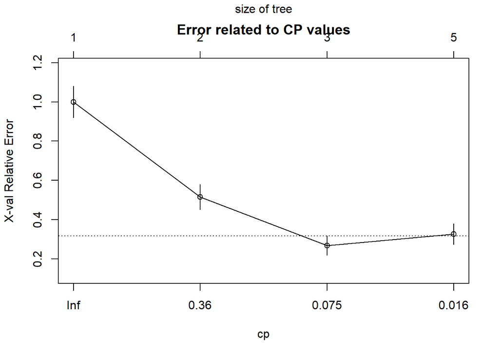

```r
plotcp(Ionosphere.tree.train, main="Error related to CP values")
```

To so, we’ll acquire the complexity parameter (CP) leading to the lowest error:

```r
min_iono <- which.min(Ionosphere.tree.train$cptable[, "xerror"])
opt_cp <- Ionosphere.tree.train$cptable[min_iono, "CP"]
opt_cp
```

```
## [1] 0.02475248
```

```r
Ionosphere.tree.train = rpart(formula = Class ~ V1 + V2 + V3 + V4 + V5 + V6 + V7 + V8 + V9 + V10 + V11 + V12 + V13 + V14 + V15 + V16 + V17 + V18 + V19 + V20 + V21 + V22 + V23 + V24 + V25 + V26 + V27 + V28 + V29 + V30 + V31 + V32 + V33 + V34, data = Ionosphere.train, method="class", cp=opt_cp)
pred = predict(Ionosphere.tree.train, Ionosphere.test, type="class")
after_cp_a <- mean(pred==Ionosphere.test$Class)
after_cp_a
```

```
## [1] 0.8285714
```

and the balanced accuracy:

```r
after_cp_ba <- bal_accuracy_vec(pred, truth=Ionosphere.test$Class, estimator="binary")
after_cp_ba
```

```
## [1] 0.8044444
```

Which are both better than before.

```r
cfm = confusionMatrix(pred, reference=Ionosphere.test$Class)
cfm
```

```
## Confusion Matrix and Statistics
##
##           Reference
## Prediction bad good
##       bad   18    5
##       good   7   40
##
##                Accuracy : 0.8286
##                  95% CI : (0.7197, 0.9082)
##     No Information Rate : 0.6429
##     P-Value [Acc > NIR] : 0.0005219
##
##                   Kappa : 0.6199
##
##  Mcnemar's Test P-Value : 0.7728300
##
##             Sensitivity : 0.7200
##             Specificity : 0.8889
##          Pos Pred Value : 0.7826
##          Neg Pred Value : 0.8511
##              Prevalence : 0.3571
##          Detection Rate : 0.2571
##    Detection Prevalence : 0.3286
##       Balanced Accuracy : 0.8044
##
##        'Positive' Class : bad
##
```

```r
print(xtable(cfm$table, type="latex"), file="confusion_matrix.tex")
```

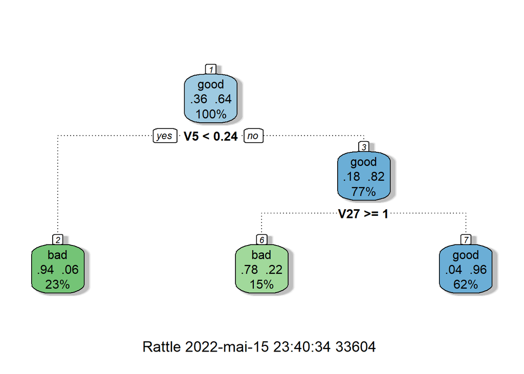

```r
fancyRpartPlot(Ionosphere.tree.train)
```

## Random forest

### Default parameters

Now we will compute a random forest in the hope for a better accuracy score, using the `randomForest` library:

```r
rf = randomForest(formula = Class ~ V1 + V2 + V3 + V4 + V5 + V6 + V7 + V8 + V9 + V10 + V11 + V12 + V13 + V14 + V15 + V16 + V17 + V18 + V19 + V20 + V21 + V22 + V23 + V24 + V25 + V26 + V27 + V28 + V29 + V30 + V31 + V32 + V33 + V34, data = Ionosphere.train)
print(rf)
```

```
##
## Call:
##  randomForest(formula = Class ~ V1 + V2 + V3 + V4 + V5 + V6 +      V7 + V8 + V9 + V10 + V11 + V12 + V13 + V14 + V15 + V16 +      V17 + V18 + V19 + V20 + V21 + V22 + V23 + V24 + V25 + V26 +      V27 + V28 + V29 + V30 + V31 + V32 + V33 + V34, data = Ionosphere.train)
##                Type of random forest: classification
##                      Number of trees: 500
## No. of variables tried at each split: 5
##
##         OOB estimate of  error rate: 5.69%
## Confusion matrix:
##      bad good class.error
## bad   91   10  0.09900990
## good   6  174  0.03333333
```

```r
pred = predict(rf, Ionosphere.test, type="class")
table(pred=pred, true=Ionosphere.test$Class)
```

```
##       true
## pred   bad good
##   bad   20    1
##   good   5   44
```

```r
paste(mean(pred==Ionosphere.test$Class), bal_accuracy_vec(pred, truth=Ionosphere.test$Class, estimator="binary"))
```

```
## [1] "0.914285714285714 0.888888888888889"
```

### Optimal number of variables

We will try to find the optimal number of variable used in our trees. To do so, we will iterate over a range of variable number and plot the OOB error rate.

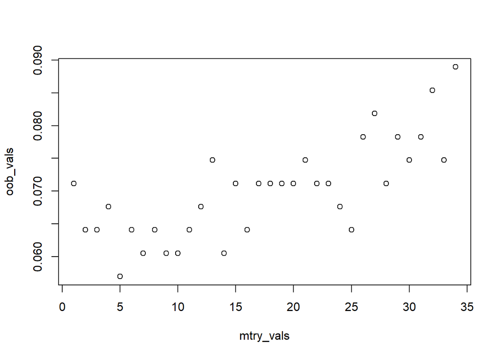

```r
oob_per_mtry <- function(mtry){
  model = randomForest(formula = Class ~ V1 + V2 + V3 + V4 + V5 + V6 + V7 + V8 + V9 + V10 + V11 + V12 + V13 + V14 + V15 + V16 + V17 + V18 + V19 + V20 + V21 + V22 + V23 + V24 + V25 + V26 + V27 + V28 + V29 + V30 + V31 + V32 + V33 + V34, data = Ionosphere.train, ntree=500, mtry=mtry)

  return(model$err.rate[498,1])
}

mtry_vals = c(1:34)
oob_vals = lapply(mtry_vals, oob_per_mtry)
plot(mtry_vals, oob_vals)
```

```r
model = randomForest(formula = Class ~ V1 + V2 + V3 + V4 + V5 + V6 + V7 + V8 + V9 + V10 + V11 + V12 + V13 + V14 + V15 + V16 + V17 + V18 + V19 + V20 + V21 + V22 + V23 + V24 + V25 + V26 + V27 + V28 + V29 + V30 + V31 + V32 + V33 + V34, data = Ionosphere.train, ntree=500, mtry=10)
print(rf)
```

```
##
## Call:
##  randomForest(formula = Class ~ V1 + V2 + V3 + V4 + V5 + V6 +      V7 + V8 + V9 + V10 + V11 + V12 + V13 + V14 + V15 + V16 +      V17 + V18 + V19 + V20 + V21 + V22 + V23 + V24 + V25 + V26 +      V27 + V28 + V29 + V30 + V31 + V32 + V33 + V34, data = Ionosphere.train)
##                Type of random forest: classification
##                      Number of trees: 500
## No. of variables tried at each split: 5
##
##         OOB estimate of  error rate: 5.69%
## Confusion matrix:
##      bad good class.error
## bad   91   10  0.09900990
## good   6  174  0.03333333
```

```r
pred = predict(rf, Ionosphere.test, type="class")
table(pred=pred, true=Ionosphere.test$Class)
```

```
##       true
## pred   bad good
##   bad   20    1
##   good   5   44
```

```r
paste(mean(pred==Ionosphere.test$Class), bal_accuracy_vec(pred, truth=Ionosphere.test$Class, estimator="binary"))
```

```
## [1] "0.914285714285714 0.888888888888889"
```

### Tree numbers

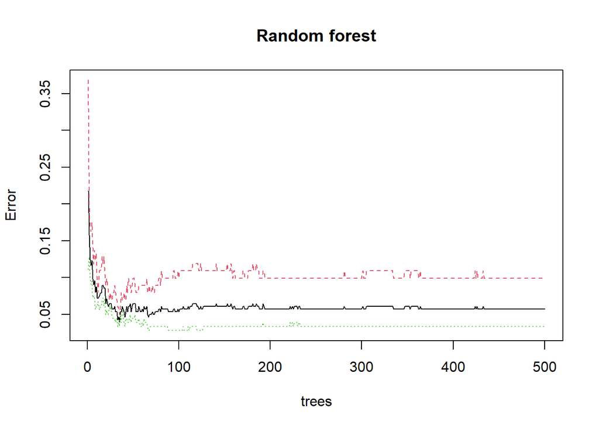

```r
plot(rf, main="Random forest")
```

```r
rf = randomForest(formula = Class ~ V1 + V2 + V3 + V4 + V5 + V6 + V7 + V8 + V9 + V10 + V11 + V12 + V13 + V14 + V15 + V16 + V17 + V18 + V19 + V20 + V21 + V22 + V23 + V24 + V25 + V26 + V27 + V28 + V29 + V30 + V31 + V32 + V33 + V34, data = Ionosphere.train, ntree=130)
rf
```

```
##
## Call:
##  randomForest(formula = Class ~ V1 + V2 + V3 + V4 + V5 + V6 +      V7 + V8 + V9 + V10 + V11 + V12 + V13 + V14 + V15 + V16 +      V17 + V18 + V19 + V20 + V21 + V22 + V23 + V24 + V25 + V26 +      V27 + V28 + V29 + V30 + V31 + V32 + V33 + V34, data = Ionosphere.train,      ntree = 130)
##                Type of random forest: classification
##                      Number of trees: 130
## No. of variables tried at each split: 5
##
##         OOB estimate of  error rate: 7.47%
## Confusion matrix:
##      bad good class.error
## bad   88   13  0.12871287
## good   8  172  0.04444444
```

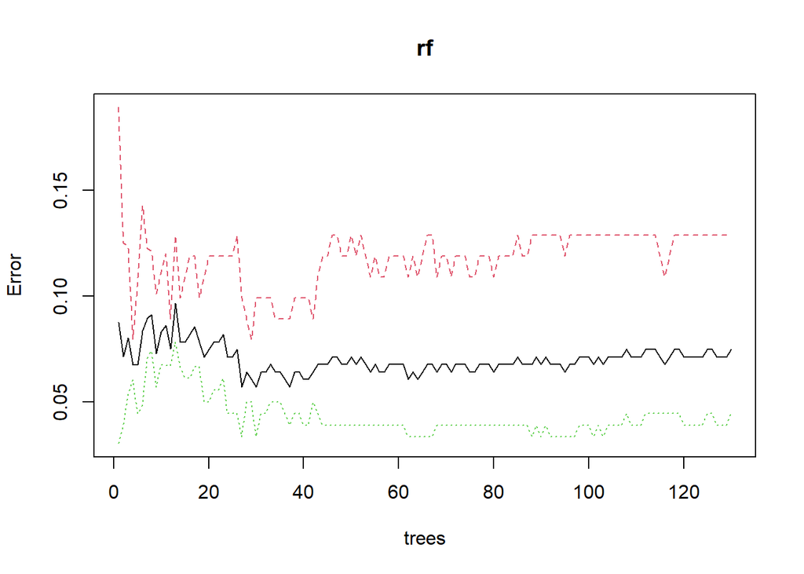

```r
plot(rf)
```

We then use this Random Forest to predict the test data:

```r
pred = predict(rf, Ionosphere.test, type="class")
table(pred=pred, true=Ionosphere.test$Class)
```

```
##       true
## pred   bad good
##   bad   20    1
##   good   5   44
```

We still have a more “good” values that were supposed to be classified as “bad” than the contrary but we have a way better accuracy (whether it is simple or balanced):

```r
paste(mean(pred==Ionosphere.test$Class), bal_accuracy_vec(pred, truth=Ionosphere.test$Class, estimator="binary"))
```

```
## [1] "0.914285714285714 0.888888888888889"
```

## Going further with this model with feature engineering

From a purely physical point of view, we could also take into account the norm of the electromagnetic field into consideration to state whether a signal is “good” or “bad”. Therefore, we’ll add the norm of each couple of measurement (real and complex values) and study its influence on the Random Forest performances.

```r
v_names = colnames(Ionosphere)[3:34]
norms_list <- vector(mode = "list", length = 16)

for(i in 1:(length(v_names)/2)){
  #Ionosphere[v_names[i]] = as.numeric(Ionosphere[v_names[i]])
  #Ionosphere[v_names[i+1]] = as.numeric(Ionosphere[v_names[i+1]])

  # To compute the squared norm
  print(paste(i, v_names[2*i - 1], v_names[2*i]))
  norms_list[i] = (Ionosphere[v_names[2*i]])**2 + (Ionosphere[v_names[2*i-1]])**2
}
```

```
## [1] "1 V3 V4"
## [1] "2 V5 V6"
## [1] "3 V7 V8"
## [1] "4 V9 V10"
## [1] "5 V11 V12"
## [1] "6 V13 V14"
## [1] "7 V15 V16"
## [1] "8 V17 V18"
## [1] "9 V19 V20"
## [1] "10 V21 V22"
## [1] "11 V23 V24"
## [1] "12 V25 V26"
## [1] "13 V27 V28"
## [1] "14 V29 V30"
## [1] "15 V31 V32"
## [1] "16 V33 V34"
```

```r
Ionosphere.with_norms = cbind(Ionosphere, norms_list)

colnames(Ionosphere.with_norms) <- append(colnames(Ionosphere), c("N1", "N2", "N3", "N4", "N5", "N6", "N7", "N8", "N9", "N10", "N11", "N12", "N13", "N14", "N15", "N16"))
```

We reapply the train/test separation:

```r
library(caret)

train_samples <- Ionosphere.with_norms$Class %>% # return the indexes of the rows
      createDataPartition(p = 0.8, list = FALSE)

Ionosphere.with_norms.train <- Ionosphere.with_norms[train_samples, ]
Ionosphere.with_norms.test <- Ionosphere.with_norms[-train_samples, ]

split_stats = rbind(summary(Ionosphere.with_norms$Class)/nrow(Ionosphere.with_norms)*100, summary(Ionosphere.with_norms.train$Class)/nrow(Ionosphere.with_norms.train)*100, summary(Ionosphere.with_norms.test$Class)/nrow(Ionosphere.with_norms.test)*100)

print(split_stats)
```

```
##           bad     good
## [1,] 35.89744 64.10256
## [2,] 35.94306 64.05694
## [3,] 35.71429 64.28571
```

Then compute a new randomForest:

```r
# To get variables names to sum
for(v in colnames(Ionosphere.with_norms)[-35]){cat(paste(v,"+ "))}
```

```
## V1 + V2 + V3 + V4 + V5 + V6 + V7 + V8 + V9 + V10 + V11 + V12 + V13 + V14 + V15 + V16 + V17 + V18 + V19 + V20 + V21 + V22 + V23 + V24 + V25 + V26 + V27 + V28 + V29 + V30 + V31 + V32 + V33 + V34 + N1 + N2 + N3 + N4 + N5 + N6 + N7 + N8 + N9 + N10 + N11 + N12 + N13 + N14 + N15 + N16 +
```

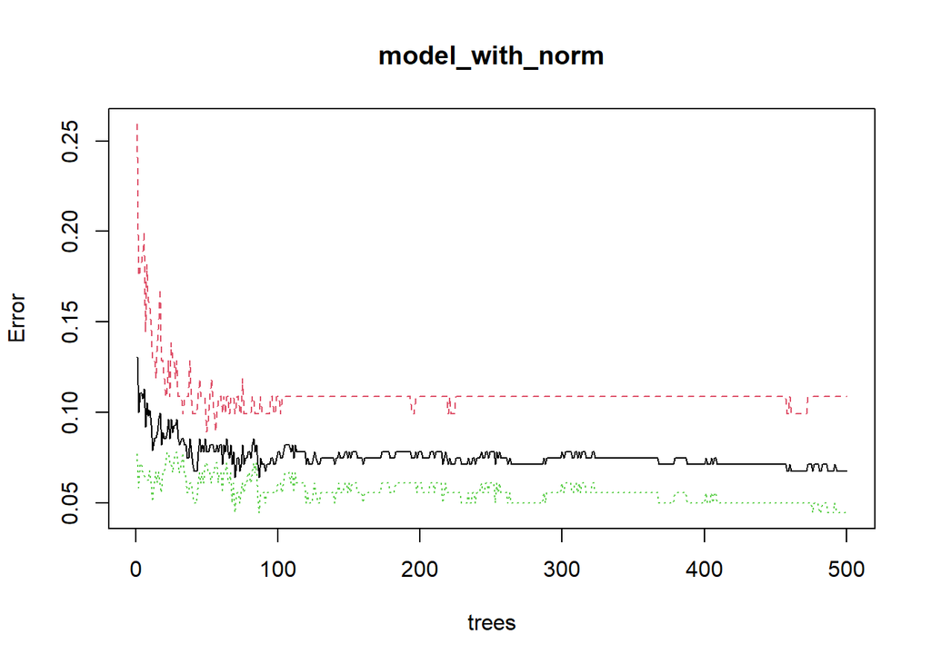

```r
model_with_norm = randomForest(formula = Class ~ V1 + V2 + V3 + V4 + V5 + V6 + V7 + V8 + V9 + V10 + V11 + V12 + V13 + V14 + V15 + V16 + V17 + V18 + V19 + V20 + V21 + V22 + V23 + V24 + V25 + V26 + V27 + V28 + V29 + V30 + V31 + V32 + V33 + V34 + N1 + N2 + N3 + N4 + N5 + N6 + N7 + N8 + N9 + N10 + N11 + N12 + N13 + N14 + N15 + N16, data = Ionosphere.with_norms.train)
plot(model_with_norm)
```

```r
model_with_norm
```

```
##
## Call:
##  randomForest(formula = Class ~ V1 + V2 + V3 + V4 + V5 + V6 +      V7 + V8 + V9 + V10 + V11 + V12 + V13 + V14 + V15 + V16 +      V17 + V18 + V19 + V20 + V21 + V22 + V23 + V24 + V25 + V26 +      V27 + V28 + V29 + V30 + V31 + V32 + V33 + V34 + N1 + N2 +      N3 + N4 + N5 + N6 + N7 + N8 + N9 + N10 +…
##                Type of random forest: classification
##                      Number of trees: 500
## No. of variables tried at each split: 7
##
##         OOB estimate of  error rate: 6.76%
## Confusion matrix:
##      bad good class.error
## bad   90   11  0.10891089
## good   8  172  0.04444444
```

Performances:

```r
pred = predict(model_with_norm, Ionosphere.with_norms.test, type="class")
table(pred=pred, true=Ionosphere.with_norms.test$Class)
```

```
##       true
## pred   bad good
##   bad   20    1
##   good   5   44
```

```r
paste(mean(pred==Ionosphere.with_norms.test$Class), bal_accuracy_vec(pred, truth=Ionosphere.with_norms.test$Class, estimator="binary"))
```

```
## [1] "0.914285714285714 0.888888888888889"
```

### Number of variables

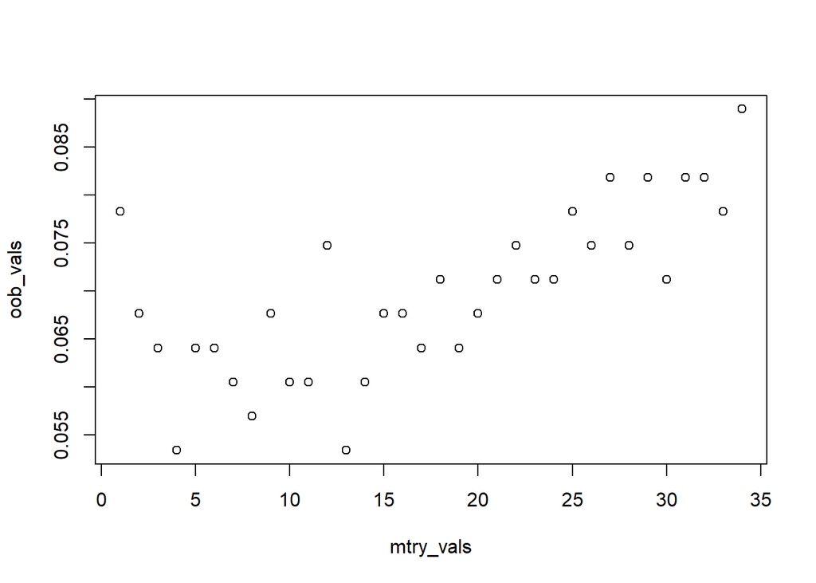

```r
oob_per_mtry <- function(mtry){
  model = randomForest(formula = Class ~ V1 + V2 + V3 + V4 + V5 + V6 + V7 + V8 + V9 + V10 + V11 + V12 + V13 + V14 + V15 + V16 + V17 + V18 + V19 + V20 + V21 + V22 + V23 + V24 + V25 + V26 + V27 + V28 + V29 + V30 + V31 + V32 + V33 + V34, data = Ionosphere.train, ntree=500, mtry=mtry)

  return(model$err.rate[498,1])
}

mtry_vals = c(1:34)
oob_vals = lapply(mtry_vals, oob_per_mtry)
plot(mtry_vals, oob_vals)
```

```r
model_with_norm = randomForest(formula = Class ~ V1 + V2 + V3 + V4 + V5 + V6 + V7 + V8 + V9 + V10 + V11 + V12 + V13 + V14 + V15 + V16 + V17 + V18 + V19 + V20 + V21 + V22 + V23 + V24 + V25 + V26 + V27 + V28 + V29 + V30 + V31 + V32 + V33 + V34 + N1 + N2 + N3 + N4 + N5 + N6 + N7 + N8 + N9 + N10 + N11 + N12 + N13 + N14 + N15 + N16, data = Ionosphere.with_norms.train, mtry=6)
model_with_norm
```

```
##
## Call:
##  randomForest(formula = Class ~ V1 + V2 + V3 + V4 + V5 + V6 +      V7 + V8 + V9 + V10 + V11 + V12 + V13 + V14 + V15 + V16 +      V17 + V18 + V19 + V20 + V21 + V22 + V23 + V24 + V25 + V26 +      V27 + V28 + V29 + V30 + V31 + V32 + V33 + V34 + N1 + N2 +      N3 + N4 + N5 + N6 + N7 + N8 + N9 + N10 +…
##                Type of random forest: classification
##                      Number of trees: 500
## No. of variables tried at each split: 6
##
##         OOB estimate of  error rate: 7.47%
## Confusion matrix:
##      bad good class.error
## bad   90   11  0.10891089
## good  10  170  0.05555556
```

Performances:

```r
pred = predict(model_with_norm, Ionosphere.with_norms.test, type="class")
table(pred=pred, true=Ionosphere.with_norms.test$Class)
```

```
##       true
## pred   bad good
##   bad   20    1
##   good   5   44
```

```r
paste(mean(pred==Ionosphere.with_norms.test$Class), bal_accuracy_vec(pred, truth=Ionosphere.with_norms.test$Class, estimator="binary"))
```

```
## [1] "0.914285714285714 0.888888888888889"
```

### Number of trees

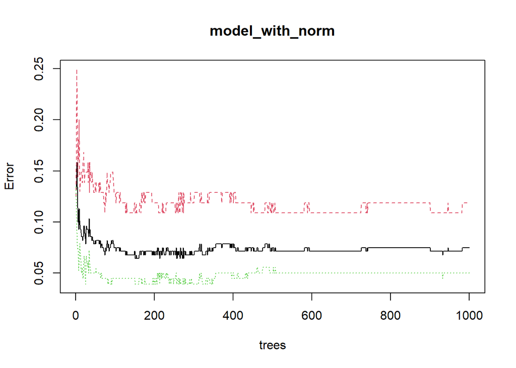

```r
model_with_norm = randomForest(formula = Class ~ V1 + V2 + V3 + V4 + V5 + V6 + V7 + V8 + V9 + V10 + V11 + V12 + V13 + V14 + V15 + V16 + V17 + V18 + V19 + V20 + V21 + V22 + V23 + V24 + V25 + V26 + V27 + V28 + V29 + V30 + V31 + V32 + V33 + V34 + N1 + N2 + N3 + N4 + N5 + N6 + N7 + N8 + N9 + N10 + N11 + N12 + N13 + N14 + N15 + N16, data = Ionosphere.with_norms.train, mtry=6, ntree=1000)
plot(model_with_norm)
```

```r
model_with_norm
```

```
##
## Call:
##  randomForest(formula = Class ~ V1 + V2 + V3 + V4 + V5 + V6 +      V7 + V8 + V9 + V10 + V11 + V12 + V13 + V14 + V15 + V16 +      V17 + V18 + V19 + V20 + V21 + V22 + V23 + V24 + V25 + V26 +      V27 + V28 + V29 + V30 + V31 + V32 + V33 + V34 + N1 + N2 +      N3 + N4 + N5 + N6 + N7 + N8 + N9 + N10 +…
##                Type of random forest: classification
##                      Number of trees: 1000
## No. of variables tried at each split: 6
##
##         OOB estimate of  error rate: 7.47%
## Confusion matrix:
##      bad good class.error
## bad   89   12   0.1188119
## good   9  171   0.0500000
```

Minimal error seems around 300, we’ll recompute to zoom in

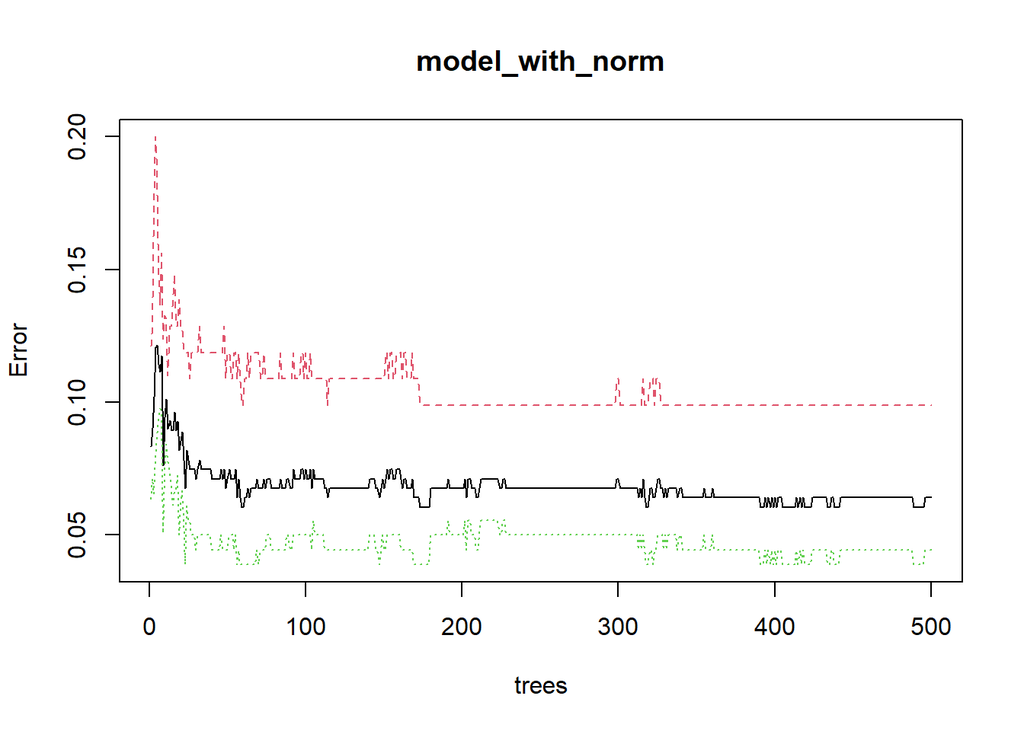

```r
model_with_norm = randomForest(formula = Class ~ V1 + V2 + V3 + V4 + V5 + V6 + V7 + V8 + V9 + V10 + V11 + V12 + V13 + V14 + V15 + V16 + V17 + V18 + V19 + V20 + V21 + V22 + V23 + V24 + V25 + V26 + V27 + V28 + V29 + V30 + V31 + V32 + V33 + V34 + N1 + N2 + N3 + N4 + N5 + N6 + N7 + N8 + N9 + N10 + N11 + N12 + N13 + N14 + N15 + N16, data = Ionosphere.with_norms.train, mtry=6, ntree=500)
plot(model_with_norm)
```

```r
model_with_norm
```

```
##
## Call:
##  randomForest(formula = Class ~ V1 + V2 + V3 + V4 + V5 + V6 +      V7 + V8 + V9 + V10 + V11 + V12 + V13 + V14 + V15 + V16 +      V17 + V18 + V19 + V20 + V21 + V22 + V23 + V24 + V25 + V26 +      V27 + V28 + V29 + V30 + V31 + V32 + V33 + V34 + N1 + N2 +      N3 + N4 + N5 + N6 + N7 + N8 + N9 + N10 +…
##                Type of random forest: classification
##                      Number of trees: 500
## No. of variables tried at each split: 6
##
##         OOB estimate of  error rate: 6.41%
## Confusion matrix:
##      bad good class.error
## bad   91   10  0.09900990
## good   8  172  0.04444444
```

```r
model_with_norm = randomForest(formula = Class ~ V1 + V2 + V3 + V4 + V5 + V6 + V7 + V8 + V9 + V10 + V11 + V12 + V13 + V14 + V15 + V16 + V17 + V18 + V19 + V20 + V21 + V22 + V23 + V24 + V25 + V26 + V27 + V28 + V29 + V30 + V31 + V32 + V33 + V34 + N1 + N2 + N3 + N4 + N5 + N6 + N7 + N8 + N9 + N10 + N11 + N12 + N13 + N14 + N15 + N16, data = Ionosphere.with_norms.train, mtry=6, ntree=100)
```

Performances:

```r
pred = predict(model_with_norm, Ionosphere.with_norms.test, type="class")
table(pred=pred, true=Ionosphere.with_norms.test$Class)
```

```
##       true
## pred   bad good
##   bad   20    1
##   good   5   44
```

```r
paste(mean(pred==Ionosphere.with_norms.test$Class), bal_accuracy_vec(pred, truth=Ionosphere.with_norms.test$Class, estimator="binary"))
```

```
## [1] "0.914285714285714 0.888888888888889"
```

Important features

```r
model_with_norm$importance
```

```
##     MeanDecreaseGini
## V1        0.01666667
## V2        0.00000000
## V3        9.14678532
## V4        1.17432441
## V5       12.82825996
## V6        1.92174273
## V7        6.49702527
## V8        1.69732744
## V9        0.72738224
## V10       1.24829976
## V11       0.51471641
## V12       1.08336629
## V13       0.54144067
## V14       1.21239958
## V15       0.46797983
## V16       0.80712383
## V17       0.58878953
## V18       0.97422430
## V19       0.34023176
## V20       0.41149150
## V21       1.44623648
## V22       0.55428567
## V23       0.55742812
## V24       0.91930470
## V25       0.42120190
## V26       0.35256237
## V27       5.65099384
## V28       0.96569696
## V29       1.67832060
## V30       0.30906800
## V31       0.91313737
## V32       0.85092138
## V33       1.26095731
## V34       0.97866932
## N1        3.42150987
## N2        4.35356196
## N3        5.15014235
## N4        3.35760991
## N5        1.64103295
## N6        4.26203947
## N7        5.13860088
## N8        2.82425514
## N9        4.31784859
## N10       4.06943159
## N11       3.71081965
## N12       2.23213849
## N13       7.87412539
## N14       3.78850108
## N15       5.85922338
## N16       7.85923193
```